# Estimating Quality of Wines with Regression/Model Trees

Yuchin Pan

January 23, 2017

Looking to employ Machine Learning to assist with rating the quality of wine. Using Regression and Model trees we will create a system that mimicks expert wine raters. Decision Trees result in a model this allows winemakers to understand the qualities that compose of a top wine. As this also removes the human element, it results in a more objective and consistent system.

# Collecting and Exploring the Data

Working with the UCI Machine Learning Data Repository’s data on white wine. This includes examples from Portugal- one of the leading wine-producing countries. While factors may differ between red and white, we will look at popular white-wines.

This data includes information on 11 chemical properties in 4,898 wine samples. These include components like sugar content, chlorides, pH and density. These were evaluated in a blind tasting of panels with no less than 3 judges on a quality scale of 0 (very bad) to 10 (excellent). If judges disagreed about the rating, the median value was used.

```r
wine <- read.csv("whitewines.csv")
str(wine)
```

```
## 'data.frame':    4898 obs. of  12 variables:
##  $ fixed.acidity       : num  7 6.3 8.1 7.2 7.2 8.1 6.2 7 6.3 8.1 ...
##  $ volatile.acidity    : num  0.27 0.3 0.28 0.23 0.23 0.28 0.32 0.27 0.3 0.22 ...
##  $ citric.acid         : num  0.36 0.34 0.4 0.32 0.32 0.4 0.16 0.36 0.34 0.43 ...
##  $ residual.sugar      : num  20.7 1.6 6.9 8.5 8.5 6.9 7 20.7 1.6 1.5 ...
##  $ chlorides           : num  0.045 0.049 0.05 0.058 0.058 0.05 0.045 0.045 0.049 0.044 ...
##  $ free.sulfur.dioxide : num  45 14 30 47 47 30 30 45 14 28 ...
##  $ total.sulfur.dioxide: num  170 132 97 186 186 97 136 170 132 129 ...
##  $ density             : num  1.001 0.994 0.995 0.996 0.996 ...
##  $ pH                  : num  3 3.3 3.26 3.19 3.19 3.26 3.18 3 3.3 3.22 ...
##  $ sulphates           : num  0.45 0.49 0.44 0.4 0.4 0.44 0.47 0.45 0.49 0.45 ...
##  $ alcohol             : num  8.8 9.5 10.1 9.9 9.9 10.1 9.6 8.8 9.5 11 ...
##  $ quality             : int  6 6 6 6 6 6 6 6 6 6 ...
```

Contains 12 variables which are numeric aside from quality which is an integer value. The benefit of using trees is that we do not need to normalize or standardize the features.

Let’s look at the distribution

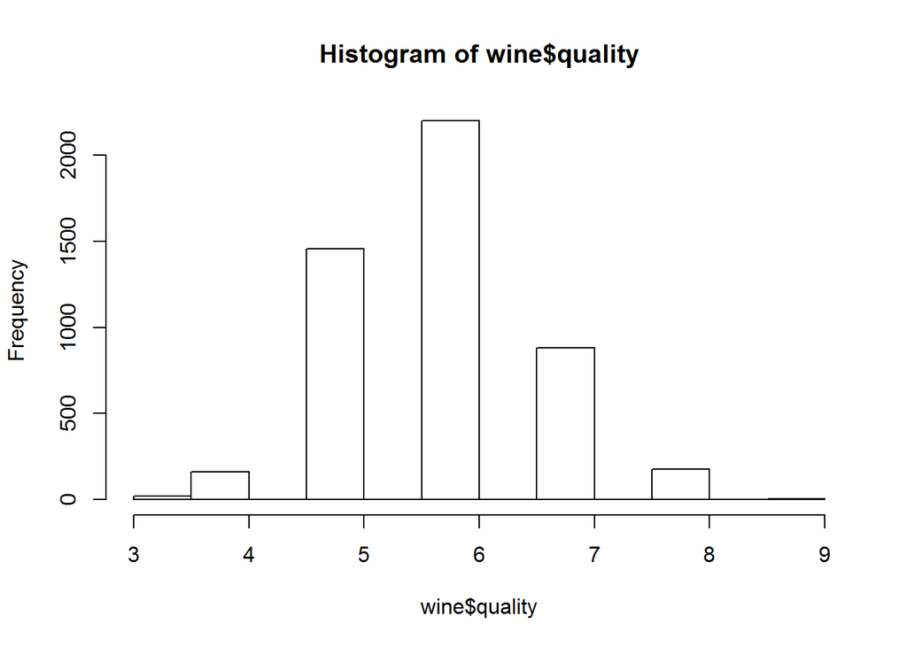

```r
hist(wine$quality)
```

```r
summary(wine)
```

```
##  fixed.acidity    volatile.acidity  citric.acid     residual.sugar
##  Min.   : 3.800   Min.   :0.0800   Min.   :0.0000   Min.   : 0.600
##  1st Qu.: 6.300   1st Qu.:0.2100   1st Qu.:0.2700   1st Qu.: 1.700
##  Median : 6.800   Median :0.2600   Median :0.3200   Median : 5.200
##  Mean   : 6.855   Mean   :0.2782   Mean   :0.3342   Mean   : 6.391
##  3rd Qu.: 7.300   3rd Qu.:0.3200   3rd Qu.:0.3900   3rd Qu.: 9.900
##  Max.   :14.200   Max.   :1.1000   Max.   :1.6600   Max.   :65.800
##    chlorides       free.sulfur.dioxide total.sulfur.dioxide
##  Min.   :0.00900   Min.   :  2.00      Min.   :  9.0
##  1st Qu.:0.03600   1st Qu.: 23.00      1st Qu.:108.0
##  Median :0.04300   Median : 34.00      Median :134.0
##  Mean   :0.04577   Mean   : 35.31      Mean   :138.4
##  3rd Qu.:0.05000   3rd Qu.: 46.00      3rd Qu.:167.0
##  Max.   :0.34600   Max.   :289.00      Max.   :440.0
##     density             pH          sulphates         alcohol
##  Min.   :0.9871   Min.   :2.720   Min.   :0.2200   Min.   : 8.00
##  1st Qu.:0.9917   1st Qu.:3.090   1st Qu.:0.4100   1st Qu.: 9.50
##  Median :0.9937   Median :3.180   Median :0.4700   Median :10.40
##  Mean   :0.9940   Mean   :3.188   Mean   :0.4898   Mean   :10.51
##  3rd Qu.:0.9961   3rd Qu.:3.280   3rd Qu.:0.5500   3rd Qu.:11.40
##  Max.   :1.0390   Max.   :3.820   Max.   :1.0800   Max.   :14.20
##     quality
##  Min.   :3.000
##  1st Qu.:5.000
##  Median :6.000
##  Mean   :5.878
##  3rd Qu.:6.000
##  Max.   :9.000
```

This data looks fairly normal, which makes intuitive sense. Most wines are likely to be average with a few top notch or very poor wines. This is seen in the summary as the mean and median of quality are very close to one another.

Since the wine data is already sorted randomly we can proceed and divide it up into training and test data.

```r
wine_train <- wine[1:3750,]
wine_test <- wine[3751:4898,]
```

This is a 75:25 split between training and testing.

# Training a model on the data

### Regression Tree Model

For this we will use the *rpart* (recursive partition) package. This offers a good implementation of regression trees by using the **rpart()** function.

> m <- rpart(dv ~ iv, data = mydata)

dv = dependant variable iv = independant variables

```r
library(rpart)
m.rpart <- rpart(quality ~ ., data = wine_train)
m.rpart
```

```
## n= 3750
##
## node), split, n, deviance, yval
##       * denotes terminal node
##
##  1) root 3750 3140.06000 5.886933
##    2) alcohol< 10.85 2473 1510.66200 5.609381
##      4) volatile.acidity>=0.2425 1406  740.15080 5.402560
##        8) volatile.acidity>=0.4225 182   92.99451 4.994505 *
##        9) volatile.acidity< 0.4225 1224  612.34560 5.463235 *
##      5) volatile.acidity< 0.2425 1067  631.12090 5.881912 *
##    3) alcohol>=10.85 1277 1069.95800 6.424432
##      6) free.sulfur.dioxide< 11.5 93   99.18280 5.473118 *
##      7) free.sulfur.dioxide>=11.5 1184  879.99920 6.499155
##       14) alcohol< 11.85 611  447.38130 6.296236 *
##       15) alcohol>=11.85 573  380.63180 6.715532 *
```

For each node described by a list number it has a predictor with a decision point. Every node depicted with a * are terminal or lead nodes being that they come to a prediction in the end.

However this is fairly tough to look at and would be much easier visualized. For this we can use rpart.plot package to work with this

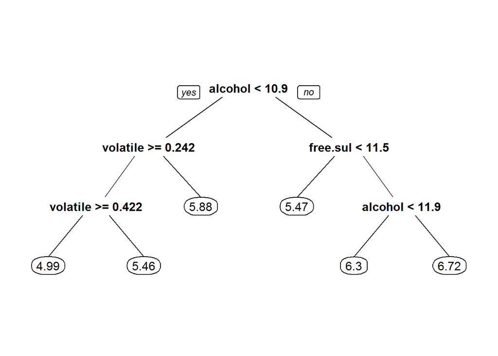

```r
library(rpart.plot)
rpart.plot(m.rpart, digits = 3)
```

There are additional parameters than digits that can help clean this tree diagram up as well. For instance, fallen.leaves forces the leaf nodes to be aligned at the bottom. type and extra parameters affect the way the decision and nodes are labeled.

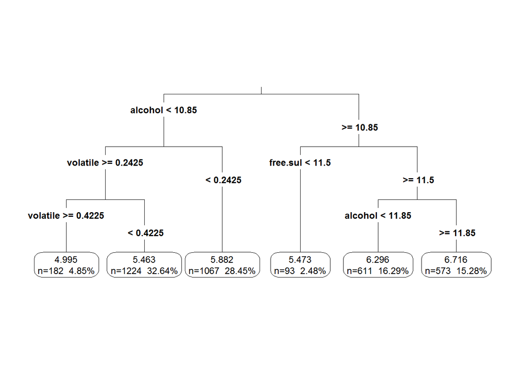

```r
rpart.plot(m.rpart, digits = 4, fallen.leaves = TRUE,
           type = 3, extra = 101)
```

# Evaluating Model Performance

To evaluate the performance we can use the predict function in conjunction with our test data. This will return a numerical data that we will store in a vector

```r
p.rpart <- predict(m.rpart, wine_test)

summary(p.rpart)
```

```
##    Min. 1st Qu.  Median    Mean 3rd Qu.    Max.
##   4.995   5.463   5.882   5.999   6.296   6.716
```

```r
summary(wine_test$quality)
```

```
##    Min. 1st Qu.  Median    Mean 3rd Qu.    Max.
##   3.000   5.000   6.000   5.848   6.000   8.000
```

These two summaries show that our model (the top one) is not properly determining the extremes of the data. While the median and mean are fairly close the maxes and mins are off by approximately 2.

We can gauge the performance of the predicted and actual quality using the correlation function to measure the relationship between two equal-length vectors.

```r
cor(p.rpart, wine_test$quality)
```

```
## [1] 0.4931608
```

This shows that our values are 0.49 related to the actual values.

## Measuring performance with mean absolute error

Anothe rway to think about a model’s performance is to see how far on average the prediction was from it’s actual value. This is called the mean absolute value (MAE).

$$MAE = \frac{1}{n}\sum_{i=1}^{n}|e_i|$$
This essentially takes the absolute value of the errors averaged to find the difference between the predicted and actual values.

```r
MAE <- function(actual, predicted) {
  mean(abs(actual - predicted))
}

MAE(p.rpart, wine_test$quality)
```

```
## [1] 0.5732104
```

With a MAE of 0.57 this implies that the difference between predicions and quality is decent. Remember the actual mean was about 5.878 so this is a fairly good performance.

# Improving Model Performance

To try and improve the model performance let’s try using a model tree. This improves on a regression tree by replace the leaf nodes with multiple linear regression models. This usually results in a more accurate result rather than a single number.

For this we can use the M5 Algorithm within the *RWeka* package.

> m <- M5P(dv ~ iv, data = mydata)

```r
library(RWeka)
m.m5p <- M5P(quality ~ ., data = wine_train)
m.m5p
```

```
## M5 pruned model tree:
## (using smoothed linear models)
##
## alcohol <= 10.85 : LM1 (2473/77.476%)
## alcohol >  10.85 :
## |   free.sulfur.dioxide <= 20.5 :
## |   |   free.sulfur.dioxide <= 10.5 : LM2 (81/104.574%)
## |   |   free.sulfur.dioxide >  10.5 : LM3 (224/87.002%)
## |   free.sulfur.dioxide >  20.5 : LM4 (972/84.073%)
##
## LM num: 1
## quality =
##  0.0777 * fixed.acidity
##  - 2.3087 * volatile.acidity
##  + 0.0732 * residual.sugar
##  + 0.0022 * free.sulfur.dioxide
##  - 155.0175 * density
##  + 0.6462 * pH
##  + 0.7923 * sulphates
##  + 0.0758 * alcohol
##  + 156.2102
##
## LM num: 2
## quality =
##  -0.0314 * fixed.acidity
##  - 0.3415 * volatile.acidity
##  + 1.7929 * citric.acid
##  + 0.1316 * residual.sugar
##  - 0.2456 * chlorides
##  + 0.1212 * free.sulfur.dioxide
##  - 178.6281 * density
##  + 0.054 * pH
##  + 0.1392 * sulphates
##  + 0.0108 * alcohol
##  + 180.6069
##
## LM num: 3
## quality =
##  -0.2019 * fixed.acidity
##  - 2.3804 * volatile.acidity
```

[output cut: 9 more lines]

```
##
## LM num: 4
## quality =
##  0.0004 * fixed.acidity
##  - 0.0325 * volatile.acidity
##  + 0.0957 * residual.sugar
##  - 5.9702 * chlorides
##  + 0.0002 * free.sulfur.dioxide
##  - 172.3931 * density
##  + 1.0123 * pH
##  + 1.1653 * sulphates
##  + 0.1542 * alcohol
##  + 171.6842
##
## Number of Rules : 4
```

The key thing to notice is that the leafs end in a linear model. Giving a more relative percentage based relationship.

```r
summary(m.m5p)
```

```
##
## === Summary ===
##
## Correlation coefficient                  0.5932
## Mean absolute error                      0.5804
## Root mean squared error                  0.7367
## Relative absolute error                 83.3671 %
## Root relative squared error             80.507  %
## Total Number of Instances             3750
```

```r
p.m5p <- predict(m.m5p, wine_test)
summary(p.m5p)
```

```
##    Min. 1st Qu.  Median    Mean 3rd Qu.    Max.
##   4.170   5.646   6.032   6.079   6.501   7.913
```

```r
summary(wine_test$quality)
```

```
##    Min. 1st Qu.  Median    Mean 3rd Qu.    Max.
##   3.000   5.000   6.000   5.848   6.000   8.000
```

While not perfect our model is now predicting a much wider range for the maxs and mins. It has also managed to stay relatively near to the correct mean and median.

```r
cor(p.m5p, wine_test$quality)
```

```
## [1] 0.531723
```

```r
MAE(wine_test$quality, p.m5p)
```

```
## [1] 0.5660352
```

With our minor change we’ve also managed to increase correlation and improve on the mean absolute error from our regression model. These make for strong algorithms to work on subjective numerical opinions. We can explain relationships between features and an outcome accurately between regression and model trees.